# Logboek_Janine

Janine Postmus

2026-05-08

Logboek van Janine Postmus  
Aangemaakt op 04-05-2026  
Project voor Omics, periode 8, studie bio-informatica  
Projectgroep: Janine Postmus, Gea Bakker, Joris Deelstra, Nicole Bovenga

### Project

https://www.sciencedirect.com/science/article/pii/S2589004225016438?via%3Dihub

Github

https://github.com/Nikkieeex/Multi-omics_lypolysis_brown_adipocytes

#### Taakverdeling

Stappen moeten chronologisch:

1. Artikel lezen: Multi-omics analysis of thermogenic lipolysis in brown adipocytes
2. Vectorize data (Joris)  
   Joris heeft alle data gedownload en we kijken naar welke bestanden nuttig zijn voor ons. Er zitten ook nog .raw data tussen en alle drie omics mogen nog gemapped worden tegen referentie genoom.  
   Wanneer deze eerste stap is afgerond gaat Joris een word document opstellen voor ons artikel.
3. Ieder een omics (Gea, Janine, Nicole)  
   Transcriptomics: Gea  
   Metabolomics: Janine  
   Proteomics: Nicole  
   Hier duidt Tsjerk om 3 veranderingen.  
   Log transform, Goed kijken naar hoe de verdeling is. Kijk naar outliers en scheefheid  
   Normalize observations, Kijk naar samples dus horizontale rijen en normalize deze  
   Normalize features, Kijk naar features dus kolommen en normalize

#### Multi-omics analysis of thermogenic lipolysis in brown adipocytes

Het artikel onderzoekt wat er gebeurt in bruine vetcellen wanneer thermogene lipolyse wordt opgewekt met norepinephrine, het onderzoek richt zich op het moleculaire deel waarbij 3 omics-lagen behandeld worden namelijk transcriptomics, proteomics en metabolomics. Het doel is naast de biologische kant om ook de methodologische manier te vergelijken. Ze vergelijken de beide manieren om multi-omics-data te integreren.

In het artikel wordt een tijdlijn gebruikt na een norepinephrine-stimulatie waarbij er duidelijke veranderingen zichtbaar zijn in de multi-omics. Voornamelijk arachidonzuur, downstream metabolieten, carnitines en TCA-cycle-metabolieten lijken belangrijk te zijn bij thermogene lipolyse. Er is een experimenteel ontwerp gemaakt waarbij er gebruik is gemaakt van immortalized murine brown preadipocytes. Deze cellen zijn gedifferentieerd tot bruine adipocyten en vervolgens gestimuleerd met 1 microliter norepinephrine. Er zijn voor alle drie de omics lagen monsters genomen op 0, 4 en 24 uur. Bij metabolomics zijn er extra tijdpunten meegenomen omdat de veranderingen op dit niveau sneller gaan. Hiervoor zijn de tijdpunten 30 minuten, 1, 2 en 8 uur extra toegevoegd. Per omics laag en tijdpunt zijn er 6 replicaten gebruikt.

Bij de data integratie na de analyse zijn de verschillende omics-lagen eerst apart bekeken voor de resultaten naast elkaar gelegd zijn. De metabolomics-tijdreeks liet 3 duidelijke metabole toestanden zien. Op 0 uur is de baseline te zien, na 4 uur is er een actieve lipolyse waardoor er een acute metabole shift ontstond en na 24 uur is er sprake van een langdurige stimulatie.

Bij de proteome resultaten veranderde er visueel niet veel maar tijdens de differentiele analyse en clustering waren er wel functionele veranderingen te zien. Na 4 uur waren vooral eiwitten verhoogd die te maken hadden met mRNA-metabolisme, cellulaire stressrespons, immuunsysteemactiviteit, mitochondriale functies en lipid droplet-dynamiek. Bij 24 h waren vooral eiwitten verhoogd die te maken hadden met TCA-metabolisme, vetzuur-β-oxidatie, aminozuurmetabolisme en ketonlichaammetabolisme.

Bij de transcriptomics resultaten zijn er meerdere differentially expressed genes (DEG’s) gevonden. Sommige genen daalden over de hele tijdreeks zoals Ero1a, Sema3g, Egln3, Ffar4 en Tlcd3b. Deze zijn gelinkt aan vetmetabolisme, oxidoreductase-activiteit, PPARγ-regulatie, vrije-vetzuurreceptoren en stress/apoptose. Ucp1 was hoger geëxprimeerd na langdurige norepinephrine-stimulatie, passend bij thermogene activatie.

De vergelijking van de verschillende omics analyse suggereert dat vetzuren vrijkomen, carnitines helpen met het transport richting de mitochondrien, TCA- en energiemetabolisme reorganiseren alles, en de cellen schakelen tussen acute stressrespons en langdurige metabole aanpassing. Hierbij wordt benadrukt dat metabolomics snelle veranderingen laat zien terwijl transcriptomics en proteomics op andere tijdschalen reageren.

Er zijn nog meerdere data-analyses uitgevoerd om bijvoorbeeld de tijdpunten te scheiden van elkaar (DIABLO uit het R-package mixOmics). Ook is er gebruik gemaakt van MOFA, dit is een unsupervised factoranalyse voor multi-omics. Hierbij is een conservatief model met vie factoren gebruikt waarvan vooral factor 1 en 2 biologisch relevant waren. Hierbij kwamen opnieuw metabolieten naar voren die te maken hebben met cAMP-gerelateerde signaling, carnitines, glucose-6-phosphate, 2-oxovaleric acid, 3-methyl-2-oxopentanoate en vetzuurgebruik. Carnitines hadden verschillende tijdsprofielen, wat suggereert dat specifieke vetzuren anders worden gebruikt in acute versus langdurige lipolyse. Er is vervolgens een pathway analyse toegepast op de DIABLO en MOFA- resultaten en dit liet zien dat geintegreerde methoden beter gecoordineerde biologische responsen vangen dan losse omics-analyses.

Deze studie laat vooral zien dat thermogene lipolyse een multi-layer proces is. Hierbij laten de verschillende omics-analyses veel detail per laag aan. Geintegreerde methoden tonen gecoordineerde responsen. De auteurs benadrukken wel dat de studie in een immortalized cell line is gedaan waardoor de resultaten niet 1-op-1 naar bruine vetweefsels vertaald mogen worden.

#### Verdieping project

Om het project goed te kunnen aanvullen met een mogelijk nieuwe onderzoeksvraag is het belangrijk om te weten wat bepaalde dingen betekenen. Daarom ga ik mij hierin verdiepen.

#### Adaptieve thermogenese

Adaptieve thermogenese is een katabool proces waarbij energie-opslagmoleculen worden verbruikt. De energie wordt als warmte afgegeven als reactie op veranderingen in de omgeving. Dit proces vindt vooral plaats in bruin en beige vetweefsel. Thermogenese wordt gereguleerd door veel factoren, waaronder lipide-afgeleide paracriene en endocriene hormonen die lipokines worden genoemd. Thermogenese verwijst naar de productie van warmte om een optimale temperatuur te houden voor enzymatische reacties die essentieel zijn voor het in stand houden van leven. Deze warmteproductie draagt bij aan de energiehomeostase van het hele lichaam door chemische energie uit voedsel te gebruiken om warmte te genereren. Uiteindelijk leidt het thermogene proces tot veranderingen in de concentraties van energie-opslagmoleculen zoals glucose en lipiden, zowel in de circulatie als in de weefsels die deze moleculen opslaan of gebruiken.

### EDA Metabolomics

De verschillende omics lagen hebben we verdeeld onder elkaar zoals te lezen is in de inleiding. Ik heb de metabolomics data gesorteerd en gemapt gekregen van Joris. Dit is te vinden in: /students/2025-2026/Thema08/lipolyse/unpacked/metabolomics

#### Inladen libraries

In deze R chunk laad ik alle libraries in zodat dit overzichtelijk bij elkaar staat.

```r
library(dplyr)
library(readr)
library(tidyr)
library(tidyverse)
library(ggplot2)
library(FactoMineR)
library(PCAtools)
library(ggrepel)
library(DESeq2)
```

#### Libraries versiebeheer

```r
packages <- c(
  "dplyr",
  "readr",
  "tidyr",
  "tidyverse",
  "ggplot2",
  "FactoMineR",
  "PCAtools",
  "ggrepel",
  "DESeq2"
)

tool_versions <- data.frame(
  Tool = c("R", packages),
  Versie = c(
    R.version.string,
    sapply(packages, function(pkg) as.character(packageVersion(pkg)))
  )
)

knitr::kable(tool_versions, row.names = FALSE)
```

| Tool | Versie |
| --- | --- |
| R | R version 4.5.0 (2025-04-11) |
| dplyr | 1.2.1 |
| readr | 2.2.0 |
| tidyr | 1.3.2 |
| tidyverse | 2.0.0 |
| ggplot2 | 4.0.3 |
| FactoMineR | 2.14 |
| PCAtools | 2.20.0 |
| ggrepel | 0.9.8 |
| DESeq2 | 1.48.2 |

Ik ga eerst inventariseren welke bestanden bij elkaar horen omdat er gebruik is gemaakt van meerdere meetmethoden.

```r
setwd("/students/2025-2026/Thema08/lipolyse/unpacked/metabolomics/")
files <- list.files(pattern = "MTBLS12307")
files
```

```
##  [1] "a_MTBLS12307_GC-MS_positive__metabolite_profiling.txt"
##  [2] "a_MTBLS12307_LC-MS_negative_hilic_metabolite_profiling.txt"
##  [3] "a_MTBLS12307_LC-MS_negative_reverse-phase_metabolite_profiling-1.txt"
##  [4] "a_MTBLS12307_LC-MS_negative_reverse-phase_metabolite_profiling.txt"
##  [5] "a_MTBLS12307_LC-MS_positive_hilic_metabolite_profiling.txt"
##  [6] "a_MTBLS12307_LC-MS_positive_reverse-phase_metabolite_profiling.txt"
##  [7] "m_MTBLS12307_GC-MS_positive__metabolite_profiling_v2_maf.tsv"
##  [8] "m_MTBLS12307_LC-MS_negative_hilic_metabolite_profiling_v2_maf.tsv"
##  [9] "m_MTBLS12307_LC-MS_negative_reverse-phase_metabolite_profiling-1_v2_maf.tsv"
## [10] "m_MTBLS12307_LC-MS_negative_reverse-phase_metabolite_profiling_v2_maf.tsv"
## [11] "m_MTBLS12307_LC-MS_positive_hilic_metabolite_profiling_v2_maf.tsv"
## [12] "m_MTBLS12307_LC-MS_positive_reverse-phase_metabolite_profiling_maf.tsv"
## [13] "s_MTBLS12307.txt"
```

De bestanden zijn opgedeeld in assay, maf en sample files. deze ga ik van elkaar scheiden zodat ze makkelijker te gebruiken zijn.

```r
assay_files <- files[grepl("^a_", files)]
maf_files   <- files[grepl("^m_", files)]
sample_file <- files[grepl("^s_", files)]

assay_files
```

```
## [1] "a_MTBLS12307_GC-MS_positive__metabolite_profiling.txt"
## [2] "a_MTBLS12307_LC-MS_negative_hilic_metabolite_profiling.txt"
## [3] "a_MTBLS12307_LC-MS_negative_reverse-phase_metabolite_profiling-1.txt"
## [4] "a_MTBLS12307_LC-MS_negative_reverse-phase_metabolite_profiling.txt"
## [5] "a_MTBLS12307_LC-MS_positive_hilic_metabolite_profiling.txt"
## [6] "a_MTBLS12307_LC-MS_positive_reverse-phase_metabolite_profiling.txt"
```

```r
maf_files
```

```
## [1] "m_MTBLS12307_GC-MS_positive__metabolite_profiling_v2_maf.tsv"
## [2] "m_MTBLS12307_LC-MS_negative_hilic_metabolite_profiling_v2_maf.tsv"
## [3] "m_MTBLS12307_LC-MS_negative_reverse-phase_metabolite_profiling-1_v2_maf.tsv"
## [4] "m_MTBLS12307_LC-MS_negative_reverse-phase_metabolite_profiling_v2_maf.tsv"
## [5] "m_MTBLS12307_LC-MS_positive_hilic_metabolite_profiling_v2_maf.tsv"
## [6] "m_MTBLS12307_LC-MS_positive_reverse-phase_metabolite_profiling_maf.tsv"
```

```r
sample_file
```

```
## [1] "s_MTBLS12307.txt"
```

Ik heb nu assay, maf en sample files. Het sample file bevat informatie over de samples zelf zoals sample naam, type, treatment etcetera. Het sample file bevat samplemetadata, zoals sample naam, sample type, treatment en timepoint. De assay files beschrijven de uitgevoerde metingen en koppelen samples aan analysebestanden. De MAF files bevatten metabolietannotaties en bevat ook intensiteitswaarden.

#### Sample file

Ik ga nu het sample file inlezen om te kijken wat er allemaal in mijn data zit.

```r
setwd("/students/2025-2026/Thema08/lipolyse/unpacked/metabolomics")

sample_metadata <- read_tsv("s_MTBLS12307.txt")
colnames(sample_metadata)
```

```
##  [1] "Source Name"                    "Characteristics[Organism]"
##  [3] "Term Source REF...3"            "Term Accession Number...4"
##  [5] "Characteristics[Organism part]" "Term Source REF...6"
##  [7] "Term Accession Number...7"      "Characteristics[Variant]"
##  [9] "Term Source REF...9"            "Term Accession Number...10"
## [11] "Characteristics[Sample type]"   "Term Source REF...12"
## [13] "Term Accession Number...13"     "Protocol REF"
## [15] "Sample Name"                    "Factor Value[Timepoint]"
## [17] "Unit"                           "Term Source REF...18"
## [19] "Term Accession Number...19"     "Factor Value[Treatment]"
## [21] "Term Source REF...21"           "Term Accession Number...22"
```

Omdat de kolomnamen onnodig lang en onleesbaar zijn ga ik deze aanpassen naar leesbaardere varianten en direct de belangrijkste kolommen eruit filteren.

```r
metadata_clean <- sample_metadata %>%
  select(
    sample_name = 'Sample Name',
    variant = 'Characteristics[Variant]',
    sample_type = 'Characteristics[Sample type]',
    timepoint = 'Factor Value[Timepoint]',
    time_unit = 'Unit',
    treatment = 'Factor Value[Treatment]'
  ) %>%
  as.data.frame()

head(metadata_clean)
```

```
##                           sample_name                variant
## 1 QC_09112022_1_P1-A-2_1_23613_RP_neg preadipocyte cell line
## 2 QC_09112022_1_P1-A-2_1_23673_RP_neg preadipocyte cell line
## 3     1_0h_1_P1-B-9_1_23769_HILIC_neg preadipocyte cell line
## 4     2_0h_2_P1-C-9_1_23779_HILIC_neg preadipocyte cell line
## 5     3_0h_3_P1-E-6_1_23796_HILIC_neg preadipocyte cell line
## 6     4_0h_4_P1-B-5_1_23765_HILIC_neg preadipocyte cell line
##                     sample_type timepoint time_unit treatment
## 1 pooled quality control sample        NA      <NA>      <NA>
## 2 pooled quality control sample        NA      <NA>      <NA>
## 3           experimental sample         0      hour   control
## 4           experimental sample         0      hour   control
## 5           experimental sample         0      hour   control
## 6           experimental sample         0      hour   control
```

De sample metadata bevat informatie over de biologische oorsprong van de samples, de variant, het sampletype, het tijdspunt en de behandeling. Voor de EDA zijn vooral Sample Name, Variant, Sample type, Timepoint, time unit en Treatment relevant, omdat deze gebruikt kunnen worden om samples te groeperen en te visualiseren in PCA-analyses en heatmaps.

#### EDA Assay files

Ik ga beginnen met kijken wat er allemaal in de assay files zit om zo te bepalen welke statistische analyses ik kan uitvoeren. Ik ga per assay bestand een aantal dingen bepalen namelijk:  
-Hoeveel rijen en kolommen heeft het bestand? -Welke kolommen zijn metadata/feature-info? -Welke kolommen zijn sample-intensiteiten? -Hebben de kolommen de goede variabele? -Zijn er missende waarden of rare kolommen?

```r
setwd("/students/2025-2026/Thema08/lipolyse/unpacked/metabolomics")

assay_gc_pmp <- read_tsv(
  "a_MTBLS12307_GC-MS_positive__metabolite_profiling.txt"
)
# de functie glimpse geeft compacte samenvatting over de inhoud van het file
glimpse(assay_gc_pmp)
```

```
## Rows: 55
## Columns: 37
## $ `Sample Name`                                <chr> "0_5_centroid_GC_pos", "0…
## $ `Protocol REF...2`                           <chr> "Extraction", "Extraction…
## $ `Parameter Value[Post Extraction]`           <chr> "MOX (2% in pyridine)/BST…
## $ `Parameter Value[Derivatization]`            <chr> "silylation", "silylation…
## $ `Extract Name`                               <chr> "0_5_centroid_GC_pos", "0…
## $ `Protocol REF...6`                           <chr> "Chromatography", "Chroma…
## $ `Parameter Value[Chromatography Instrument]` <chr> "LECO Pegasus BT TOFMS", …
## $ `Term Source REF...8`                        <chr> "MTBLS", "MTBLS", "MTBLS"…
## $ `Term Accession Number...9`                  <chr> "http://www.ebi.ac.uk/met…
## $ `Parameter Value[Autosampler model]`         <chr> "GERSTEL MPS 2 autosample…
## $ `Parameter Value[Column model]`              <chr> "Rxi-5ms (0.25 µm, 0.25 m…
## $ `Parameter Value[Column type]`               <chr> "low polarity", "low pola…
## $ `Parameter Value[Guard column]`              <lgl> NA, NA, NA, NA, NA, NA, N…
```

[output cut: 24 more lines]

```r
head(assay_gc_pmp)
```

```
## # A tibble: 6 × 37
##   `Sample Name` `Protocol REF...2` Parameter Value[Post…¹ Parameter Value[Deri…²
##   <chr>         <chr>              <chr>                  <chr>
## 1 0_5_centroid… Extraction         MOX (2% in pyridine)/… silylation
## 2 0_1_centroid… Extraction         MOX (2% in pyridine)/… silylation
## 3 0_2_centroid… Extraction         MOX (2% in pyridine)/… silylation
## 4 0_3_centroid… Extraction         MOX (2% in pyridine)/… silylation
## 5 0_4_centroid… Extraction         MOX (2% in pyridine)/… silylation
## 6 0_6_centroid… Extraction         MOX (2% in pyridine)/… silylation
## # ℹ abbreviated names: ¹`Parameter Value[Post Extraction]`,
## #   ²`Parameter Value[Derivatization]`
## # ℹ 33 more variables: `Extract Name` <chr>, `Protocol REF...6` <chr>,
## #   `Parameter Value[Chromatography Instrument]` <chr>,
## #   `Term Source REF...8` <chr>, `Term Accession Number...9` <chr>,
## #   `Parameter Value[Autosampler model]` <chr>,
## #   `Parameter Value[Column model]` <chr>, …
```

Omdat er 37 kolommen zijn wil ik ze overzichtelijker maken en direct scheiden tussen sample kolommen en feature informatie om te kijken of er nuttige informatie instaat. De functie n = Inf print alle rijen overzichtelijk in combinatie met de functie tibble.

```r
colnames_assay_1 <- tibble(
  colnumber = seq_along(colnames(assay_gc_pmp)),
  colname = colnames(assay_gc_pmp)
)

print(colnames_assay_1, n = Inf)
```

```
## # A tibble: 37 × 2
##    colnumber colname
##        <int> <chr>
##  1         1 Sample Name
##  2         2 Protocol REF...2
##  3         3 Parameter Value[Post Extraction]
##  4         4 Parameter Value[Derivatization]
##  5         5 Extract Name
##  6         6 Protocol REF...6
##  7         7 Parameter Value[Chromatography Instrument]
##  8         8 Term Source REF...8
##  9         9 Term Accession Number...9
## 10        10 Parameter Value[Autosampler model]
## 11        11 Parameter Value[Column model]
## 12        12 Parameter Value[Column type]
```

[output cut: 25 more lines]

Omdat metabolomics nieuw voor mij was, heb ik ChatGPT gebruikt om een eerste interpretatie van de kolomnamen te krijgen. Deze interpretatie heb ik vervolgens gecontroleerd door de kolommen zelf in R te inspecteren en te bepalen welke kolommen metadata, annotatie of mogelijke intensiteitswaarden bevatten.

#### EDA MAF files

Ik ga eerst 1 bestand inlezen met als doel om te ontdekken welke kolommen metaboliet informatie zijn en welke kolommen sample intensiteit zijn. Deze ga ik daarna van elkaar scheiden.

```r
setwd("/students/2025-2026/Thema08/lipolyse/unpacked/metabolomics/")

maf_gc <- read_tsv("m_MTBLS12307_GC-MS_positive__metabolite_profiling_v2_maf.tsv")

colnames(maf_gc)
```

```
##  [1] "database_identifier"
##  [2] "chemical_formula"
##  [3] "smiles"
##  [4] "inchi"
##  [5] "metabolite_identification"
##  [6] "mass_to_charge"
##  [7] "fragmentation"
##  [8] "modifications"
##  [9] "charge"
## [10] "retention_time"
## [11] "taxid"
## [12] "species"
## [13] "database"
## [14] "database_version"
## [15] "reliability"
```

[output cut: 61 more lines]

```r
# Metaboliet informatie eruit hlaen
annotatie_kolommen <- c(
  "database_identifier",
  "chemical_formula",
  "smiles",
  "inchi",
  "metabolite_identification",
  "mass_to_charge",
  "retention_time",
  "fragmentation",
  "modifications",
  "charge",
  "taxonomy",
  "species",
  "database",
  "database_version",
  "reliability"
)

# Aparte tabel met alleen annotatie-informatie
annotatie_data <- maf_gc %>%
  select(any_of(annotatie_kolommen))

# Aparte tabel met alles behalve de annotatiekolommen
intensiteit_data <- maf_gc %>%
  select(-any_of(annotatie_kolommen))

# Controleren van data
head(annotatie_data)
```

```
## # A tibble: 6 × 14
##   database_identifier chemical_formula smiles       inchi metabolite_identific…¹
##   <chr>               <chr>            <chr>        <chr> <chr>
## 1 CHEBI:18064         C4H8O3           CC(CO)C(O)=O InCh… 3-hydroxyisobutyric a…
## 2 CHEBI:15344         C4H6O3           CC(=O)CC(O)… InCh… acetoacetic acid
## 3 CHEBI:28837         C8H16O2          CCCCCCCC(O)… InCh… octanoic acid
## 4 CHEBI:15428         C2H5NO2          NCC(O)=O     InCh… glycine
## 5 CHEBI:32816         C3H4O3           CC(=O)C(O)=O InCh… pyruvic acid
## 6 CHEBI:15741         C4H6O4           OC(=O)CCC(O… InCh… succinic acid
## # ℹ abbreviated name: ¹metabolite_identification
## # ℹ 9 more variables: mass_to_charge <dbl>, retention_time <dbl>,
## #   fragmentation <lgl>, modifications <lgl>, charge <lgl>, species <lgl>,
## #   database <lgl>, database_version <lgl>, reliability <lgl>
```

```r
head(intensiteit_data)
```

```
## # A tibble: 6 × 62
##   taxid uri   search_engine search_engine_score smallmolecule_abundance_sub
##   <lgl> <lgl> <lgl>         <lgl>               <lgl>
## 1 NA    NA    NA            NA                  NA
## 2 NA    NA    NA            NA                  NA
## 3 NA    NA    NA            NA                  NA
## 4 NA    NA    NA            NA                  NA
## 5 NA    NA    NA            NA                  NA
## 6 NA    NA    NA            NA                  NA
## # ℹ 57 more variables: smallmolecule_abundance_stdev_sub <lgl>,
## #   smallmolecule_abundance_std_error_sub <lgl>, `0_5_centroid_GC_pos` <lgl>,
## #   `0_1_centroid_GC_pos` <lgl>, `0_2_centroid_GC_pos` <lgl>,
## #   `0_3_centroid_GC_pos` <lgl>, `0_4_centroid_GC_pos` <lgl>,
## #   `0_6_centroid_GC_pos` <lgl>, `1_1_centroid_GC_pos` <lgl>,
## #   `1_2_centroid_GC_pos` <lgl>, `1_3_centroid_GC_pos` <lgl>,
## #   `1_4_centroid_GC_pos` <lgl>, `1_5_centroid_GC_pos` <lgl>, …
```

De kolommen met informatie zijn bruikbaar, echter de intensiteitskolommen lijken allemaal N/A te geven. Ik ga per kolom tellen hoeveel waarden er zijn die wel een getal terug geven zodat ik kan controleren of het klopt dat de intensiteitskolommen allemaal leeg lijken te zijn.

```r
gevulde_waarden <- maf_gc %>%
  summarise(across(everything(), ~sum(!is.na(.)))) %>%
  pivot_longer(
    cols = everything(),
    names_to = "kolom",
    values_to = "aantal_gevulde_waarden"
    )

gevulde_waarden
```

```
## # A tibble: 76 × 2
##    kolom                     aantal_gevulde_waarden
##    <chr>                                      <int>
##  1 database_identifier                           13
##  2 chemical_formula                              13
##  3 smiles                                        13
##  4 inchi                                         13
##  5 metabolite_identification                     13
##  6 mass_to_charge                                13
##  7 fragmentation                                  0
##  8 modifications                                  0
##  9 charge                                         0
## 10 retention_time                                13
## # ℹ 66 more rows
```

Hieruit blijkt dat er maar 7 kolommen daadwerkelijk inhoud hebben, deze inhoud bevat alleen informatie over de metabolieten. Ik laat dit nu zo staan en verwerk dit verder wanneer dit nodig is. Ik wil graag weten of er in de andere MAF files wel bruikbare bestanden zitten dus ga ik deze net zoals hierboven controleren maar dan in een for loop.

[output not shown]

[output cut: 65 more lines]

```
## Aantal kolommen met waarden: 7
## Aantal lege kolommen: 64
## Aantal numerieke kolommen: 2
##
## Kolommen met waarden:
## # A tibble: 7 × 2
##   kolom                     aantal_waarden
##   <chr>                              <int>
## 1 database_identifier                   24
## 2 chemical_formula                      24
## 3 smiles                                24
## 4 inchi                                 24
## 5 metabolite_identification             24
## 6 mass_to_charge                        24
## 7 retention_time                        24
```

De maf bestanden bevatten wel de metabolietannotaties maar geen intensiteitsannotaties. Daarom zijn de maf bestanden ook niet bruikbaar.

```r
setwd("/students/2025-2026/Thema08/lipolyse/unpacked/metabolomics/")

assay_bestanden <- list.files(pattern = "^a_")

for (bestand in assay_bestanden) {

  assay_data <- read_tsv(bestand, show_col_types = FALSE)

  # Tel per kolom hoeveel waarden NIET NA zijn
  gevulde_waarden <- assay_data %>%
    summarise(across(everything(), ~ sum(!is.na(.)))) %>%
    pivot_longer(
      cols = everything(),
      names_to = "kolom",
      values_to = "aantal_waarden"
    )

  # Kolommen waar minimaal 1 waarde in staat
  gevulde_kolommen <- gevulde_waarden %>%
    filter(aantal_waarden > 0)

  # Kolommen die helemaal leeg zijn
  lege_kolommen <- gevulde_waarden %>%
    filter(aantal_waarden == 0)

  # Aantal numerieke kolommen
  aantal_numerieke_kolommen <- assay_data %>%
    select(where(is.numeric)) %>%
    ncol()

  # Print overzicht
  cat("\n==============================\n")
  cat("Bestand:", bestand, "\n")
  cat("Aantal rijen/samples:", nrow(assay_data), "\n")
  cat("Aantal kolommen:", ncol(assay_data), "\n")
  cat("Aantal kolommen met waarden:", nrow(gevulde_kolommen), "\n")
  cat("Aantal lege kolommen:", nrow(lege_kolommen), "\n")
  cat("Aantal numerieke kolommen:", aantal_numerieke_kolommen, "\n")

  cat("\nKolommen met waarden:\n")
  print(gevulde_kolommen)
}
```

```
##
## ==============================
## Bestand: a_MTBLS12307_GC-MS_positive__metabolite_profiling.txt
## Aantal rijen/samples: 55
## Aantal kolommen: 37
## Aantal kolommen met waarden: 31
## Aantal lege kolommen: 6
## Aantal numerieke kolommen: 0
##
## Kolommen met waarden:
## # A tibble: 31 × 2
##    kolom                                      aantal_waarden
##    <chr>                                               <int>
##  1 Sample Name                                            55
##  2 Protocol REF...2                                       55
##  3 Parameter Value[Post Extraction]                       55
##  4 Parameter Value[Derivatization]                        55
##  5 Extract Name                                           55
##  6 Protocol REF...6                                       55
##  7 Parameter Value[Chromatography Instrument]             55
##  8 Term Source REF...8                                    55
##  9 Term Accession Number...9                              55
## 10 Parameter Value[Autosampler model]                     55
## # ℹ 21 more rows
```

```
##
## ==============================
## Bestand: a_MTBLS12307_LC-MS_negative_hilic_metabolite_profiling.txt
## Aantal rijen/samples: 51
## Aantal kolommen: 37
## Aantal kolommen met waarden: 28
## Aantal lege kolommen: 9
## Aantal numerieke kolommen: 0
##
## Kolommen met waarden:
## # A tibble: 28 × 2
##    kolom                                      aantal_waarden
##    <chr>                                               <int>
##  1 Sample Name                                            51
##  2 Protocol REF...2                                       51
##  3 Parameter Value[Post Extraction]                       51
##  4 Parameter Value[Derivatization]                        51
##  5 Extract Name                                           51
##  6 Protocol REF...6                                       51
##  7 Parameter Value[Chromatography Instrument]             51
##  8 Term Source REF...8                                    51
##  9 Term Accession Number...9                              51
## 10 Parameter Value[Autosampler model]                     51
## # ℹ 18 more rows
```

```
##
## ==============================
## Bestand: a_MTBLS12307_LC-MS_negative_reverse-phase_metabolite_profiling-1.txt
## Aantal rijen/samples: 56
## Aantal kolommen: 37
## Aantal kolommen met waarden: 31
## Aantal lege kolommen: 6
## Aantal numerieke kolommen: 0
##
## Kolommen met waarden:
## # A tibble: 31 × 2
##    kolom                                      aantal_waarden
##    <chr>                                               <int>
##  1 Sample Name                                            56
##  2 Protocol REF...2                                       56
##  3 Parameter Value[Post Extraction]                       56
##  4 Parameter Value[Derivatization]                        56
##  5 Extract Name                                           56
##  6 Protocol REF...6                                       56
##  7 Parameter Value[Chromatography Instrument]             56
##  8 Term Source REF...8                                    56
##  9 Term Accession Number...9                              56
## 10 Parameter Value[Autosampler model]                     56
## # ℹ 21 more rows
```

```
##
## ==============================
## Bestand: a_MTBLS12307_LC-MS_negative_reverse-phase_metabolite_profiling.txt
## Aantal rijen/samples: 50
## Aantal kolommen: 37
## Aantal kolommen met waarden: 28
## Aantal lege kolommen: 9
## Aantal numerieke kolommen: 0
##
## Kolommen met waarden:
## # A tibble: 28 × 2
##    kolom                                      aantal_waarden
##    <chr>                                               <int>
##  1 Sample Name                                            50
##  2 Protocol REF...2                                       50
##  3 Parameter Value[Post Extraction]                       50
##  4 Parameter Value[Derivatization]                        50
##  5 Extract Name                                           50
##  6 Protocol REF...6                                       50
##  7 Parameter Value[Chromatography Instrument]             50
##  8 Term Source REF...8                                    50
##  9 Term Accession Number...9                              50
## 10 Parameter Value[Autosampler model]                     50
## # ℹ 18 more rows
```

```
##
## ==============================
## Bestand: a_MTBLS12307_LC-MS_positive_hilic_metabolite_profiling.txt
## Aantal rijen/samples: 51
## Aantal kolommen: 37
## Aantal kolommen met waarden: 28
## Aantal lege kolommen: 9
## Aantal numerieke kolommen: 0
##
## Kolommen met waarden:
## # A tibble: 28 × 2
##    kolom                                      aantal_waarden
##    <chr>                                               <int>
##  1 Sample Name                                            51
##  2 Protocol REF...2                                       51
##  3 Parameter Value[Post Extraction]                       51
##  4 Parameter Value[Derivatization]                        51
##  5 Extract Name                                           51
##  6 Protocol REF...6                                       51
##  7 Parameter Value[Chromatography Instrument]             51
##  8 Term Source REF...8                                    51
##  9 Term Accession Number...9                              51
## 10 Parameter Value[Autosampler model]                     51
## # ℹ 18 more rows
```

```
##
## ==============================
## Bestand: a_MTBLS12307_LC-MS_positive_reverse-phase_metabolite_profiling.txt
## Aantal rijen/samples: 50
## Aantal kolommen: 37
## Aantal kolommen met waarden: 28
## Aantal lege kolommen: 9
## Aantal numerieke kolommen: 0
##
## Kolommen met waarden:
## # A tibble: 28 × 2
##    kolom                                      aantal_waarden
##    <chr>                                               <int>
##  1 Sample Name                                            50
##  2 Protocol REF...2                                       50
##  3 Parameter Value[Post Extraction]                       50
##  4 Parameter Value[Derivatization]                        50
##  5 Extract Name                                           50
##  6 Protocol REF...6                                       50
##  7 Parameter Value[Chromatography Instrument]             50
##  8 Term Source REF...8                                    50
##  9 Term Accession Number...9                              50
## 10 Parameter Value[Autosampler model]                     50
## # ℹ 18 more rows
```

De assay-bestanden bevatten wel metadata over de metingen, maar geen numerieke metaboliet-intensiteiten per sample die direct gebruikt kunnen worden voor PCA, clustering of differentiële analyse. Daarom zijn deze bestanden voor mijn geplande metabolomics-EDA niet geschikt.

### Tussenconclusie metabolomics

De bestanden die ik gekregen had bevat alleen metadata, daarom heb ik Marcel om hulp gevraagd. Hieruit bleek dat alleen de ruwe data beschikbaar is. Marcel heeft een script geschreven om te kijken wat hier allemaal inzit -> /students/2025-2026/Thema08/lipolyse/unpacked/metabolomics/ms-cdf-processing.R

Door middel van deze tutorial: https://bioconductor.org/packages/release/bioc/vignettes/xcms/inst/doc/xcms.html hebben we gekeken naar de chromatogrammen die gegenereerd zijn. Helaas zijn de chromatogrammen onbruikbaar omdat deze alleen pieken laten zien en geen stoffenanalyse. Hierop is er gemaild met de universiteit in Kopenhagen om te vragen of we de volledige chromatogrammen mochten gebruiken. Hierop kregen we als antwoord te horen dat dat niet mogelijk is omdat ze een interne bibliotheek hebben gebruikt voor de stoffenanalyse op de chromatogrammen. Daarom houdt het voor dit project op om met de metabolomics data te werken. We gaan dit als discussie in onze wetenschappelijke paper verwerken.

## PCA plot transcriptomics

Omdat Gea haar Rstudio moeite heeft om de PCA goed uit te voeren, bij elke uitvoering ontstaat er een ander percentage in PCA1 en PCA2, gaan we het proberen in mijn omgeving te doen. Ik gebruik een bestand met de genormaliseerde counts om de pca plot te maken. Deze data heeft Gea geproduceerd en staat in deze locatie: “/students/2025-2026/Thema08/lipolyse/unpacked/transcriptomics/genormaliseerde_counts.csv”.

### Inladen genormaliseerde counts

Ik ga eerst het bestand dat ik van Gea gekregen heb inladen en bekijken wat er allemaal inzit.

```r
setwd("/students/2025-2026/Thema08/lipolyse/unpacked/transcriptomics")

counts_csv <- read.csv("/students/2025-2026/Thema08/lipolyse/unpacked/transcriptomics/genormaliseerde_counts.csv",
header = TRUE,
stringsAsFactors = FALSE)

counts_wide <- counts_csv %>%
  select(Geneid, sample, z_score) %>%
  pivot_wider(
    names_from = sample,
    values_from = z_score
  )

counts <- counts_wide %>%
  column_to_rownames("Geneid")

head(counts)
```

```
##                    SRR32635415_Aligned.sortedByCoord.out.bam
## ENSMUSG00000104385                                -0.5227400
## ENSMUSG00000102135                                 0.6837024
## ENSMUSG00000101097                                -0.2357023
## ENSMUSG00000100764                                 0.4709504
## ENSMUSG00000100635                                 1.4309409
## ENSMUSG00000100480                                -0.1565787
##                    SRR32635416_Aligned.sortedByCoord.out.bam
## ENSMUSG00000104385                                -0.5227400
## ENSMUSG00000102135                                -1.4293231
## ENSMUSG00000101097                                -0.2357023
## ENSMUSG00000100764                                -2.5780708
## ENSMUSG00000100635                                -2.1243748
## ENSMUSG00000100480                                -3.1666663
##                    SRR32635417_Aligned.sortedByCoord.out.bam
## ENSMUSG00000104385                             -0.5227399983
## ENSMUSG00000102135                             -1.7523890007
## ENSMUSG00000101097                             -0.2357022604
## ENSMUSG00000100764                              0.8187848715
## ENSMUSG00000100635                             -0.4377507795
## ENSMUSG00000100480                             -0.0003158893
##                    SRR32635418_Aligned.sortedByCoord.out.bam
## ENSMUSG00000104385                                -0.5227400
## ENSMUSG00000102135                                -0.6810662
## ENSMUSG00000101097                                -0.2357023
## ENSMUSG00000100764                                -0.5697975
## ENSMUSG00000100635                                -0.2903620
## ENSMUSG00000100480                                -0.2634948
##                    SRR32635419_Aligned.sortedByCoord.out.bam
## ENSMUSG00000104385                                0.98058635
## ENSMUSG00000102135                               -0.93823291
## ENSMUSG00000101097                               -0.23570226
## ENSMUSG00000100764                                0.01368252
## ENSMUSG00000100635                                0.54311011
## ENSMUSG00000100480                                0.38318588
##                    SRR32635420_Aligned.sortedByCoord.out.bam
## ENSMUSG00000104385                                 0.9900996
## ENSMUSG00000102135                                -0.3621463
## ENSMUSG00000101097                                -0.2357023
## ENSMUSG00000100764                                 0.8253676
```

[output cut: 71 more lines]

```
## ENSMUSG00000100480                                 0.6957137
##                    SRR32635431_Aligned.sortedByCoord.out.bam
## ENSMUSG00000104385                                -0.5227400
## ENSMUSG00000102135                                 1.5311597
## ENSMUSG00000101097                                -0.2357023
## ENSMUSG00000100764                                -0.5983949
## ENSMUSG00000100635                                -0.3328280
## ENSMUSG00000100480                                -0.2365853
##                    SRR32635432_Aligned.sortedByCoord.out.bam
## ENSMUSG00000104385                                 0.6388054
## ENSMUSG00000102135                                 0.3016272
## ENSMUSG00000101097                                -0.2357023
## ENSMUSG00000100764                                 0.8915331
## ENSMUSG00000100635                                -0.5349539
## ENSMUSG00000100480                                 0.6859007
```

De data is goed ingeladen, Gea heeft meegekeken en we hebben vastgesteld dat dit overeenkomt met de data die zij opgeslagen heeft. Ik ga nu een pca plot maken op dezelfde manier zoals Gea dat heeft gedaan in haar logboek.

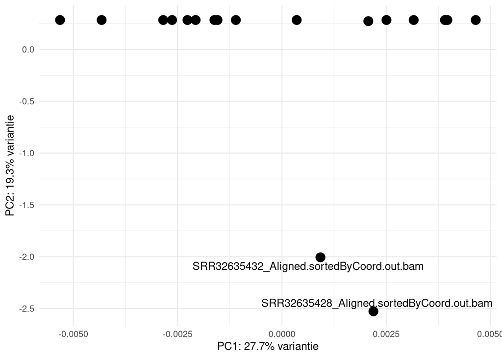

```r
setwd("/students/2025-2026/Thema08/lipolyse/unpacked/transcriptomics")

pca_input <- t(counts)

pca_result <- prcomp(pca_input, scale. = FALSE)
pca_df <- as.data.frame(pca_result$x)
pca_df$sample <- rownames(pca_df)


percent_var <- pca_result$sdev^2 / sum(pca_result$sdev^2) * 100

ggplot(pca_df, aes(x = PC1, y = PC2, label = sample)) +
  geom_point(size = 4) +
  geom_text_repel() +
  xlab(paste0("PC1: ", round(percent_var[1], 1), "% variantie")) +
  ylab(paste0("PC2: ", round(percent_var[2], 1), "% variantie")) +
  theme_minimal()
```

Omdat prcomp() deterministisch hoort te zijn bij dezelfde inputdata, wijst het veranderen van de verklaarde variantie erop dat de inputmatrix waarschijnlijk niet steeds identiek was, of dat er ergens in de preprocessing/filtering iets veranderde. Daarom hebben we de input, samplevolgorde en metadata-matching gecontroleerd en vervolgens PCAtools gebruikt als alternatieve workflow.

```r
colnames(counts) <- basename(colnames(counts))

colnames(counts) <- gsub(
  "_Aligned.sortedByCoord.out.bam",
  "",
  colnames(counts)
)

metadata <- data.frame(
  sample = c(
    "SRR32635427", "SRR32635428", "SRR32635429",
    "SRR32635430", "SRR32635431", "SRR32635432",
    "SRR32635421", "SRR32635422", "SRR32635423",
    "SRR32635424", "SRR32635425", "SRR32635426",
    "SRR32635415", "SRR32635416", "SRR32635417",
    "SRR32635418", "SRR32635419", "SRR32635420"
  ),
  group = c(
    "0 h", "0 h", "0 h",
    "0 h", "0 h", "0 h",
    "4 h", "4 h", "4 h",
    "4 h", "4 h", "4 h",
    "24 h", "24 h", "24 h",
    "24 h", "24 h", "24 h"
  )
)

rownames(metadata) <- metadata$sample

metadata <- metadata[colnames(counts), ]

identical(colnames(counts), rownames(metadata))
```

```
## [1] TRUE
```

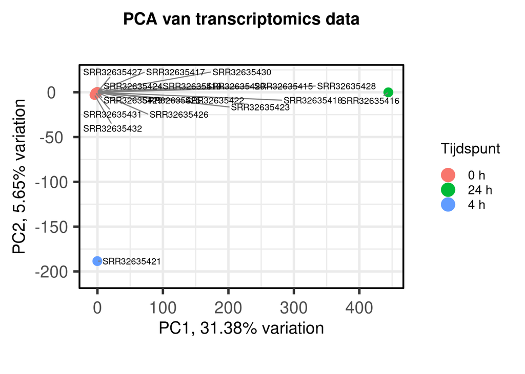

```r
p <- pca(
  mat = as.matrix(counts),
  metadata = metadata,
  removeVar = 0.1
)

biplot(
  p,
  colby = "group",
  lab = rownames(metadata),
  legendPosition = "right",
  title = "PCA van transcriptomics data",
  max.overlaps = Inf,
  labSize = 3
) +
  labs(
    color = "Tijdspunt"
  ) +
  theme( plot.title = element_text(hjust = 0.5)
  )
```

De pca blijft nu hetzelfde maar er zijn maar 3 samples. Het lijkt dat de twee uitschieters de plot bepalen en de rest van de datapunten op 1 hoop ligt. Dit is opgelost door de overlap eruit te halen zodat alle samples geplot worden. Ook zijn de twee samples die uitschieters lijken te zijn eruit gehaald. Deze samples zijn als potentiële outliers aangemerkt omdat ze in de PCA sterk buiten de overige samples lagen en daardoor de spreiding van de resterende samples domineerden. De PCA is daarom zowel mét als zonder deze samples bekeken. De versie zonder outliers wordt gebruikt om de clustering van de overige samples beter te inspecteren, niet als vervanging van de oorspronkelijke PCA.

```r
# Sample-namen opschonen in counts
colnames(counts) <- basename(colnames(counts))

colnames(counts) <- gsub(
  "_Aligned.sortedByCoord.out.bam",
  "",
  colnames(counts)
)

# Metadata maken
metadata <- data.frame(
  sample = c(
    "SRR32635427", "SRR32635428", "SRR32635429",
    "SRR32635430", "SRR32635431", "SRR32635432",
    "SRR32635421", "SRR32635422", "SRR32635423",
    "SRR32635424", "SRR32635425", "SRR32635426",
    "SRR32635415", "SRR32635416", "SRR32635417",
    "SRR32635418", "SRR32635419", "SRR32635420"
  ),
  group = c(
    "0 h", "0 h", "0 h",
    "0 h", "0 h", "0 h",
    "4 h", "4 h", "4 h",
    "4 h", "4 h", "4 h",
    "24 h", "24 h", "24 h",
    "24 h", "24 h", "24 h"
  )
)

# Outliers aangeven
outliers <- c("SRR32635416", "SRR32635421")

# Outliers verwijderen uit counts
counts_without_outliers <- counts[, !colnames(counts) %in% outliers]

# Outliers verwijderen uit metadata
metadata_without_outliers <- metadata[!metadata$sample %in% outliers, ]

# Sample-namen als rownames zetten
rownames(metadata_without_outliers) <- metadata_without_outliers$sample

# Metadata in dezelfde volgorde zetten als de kolommen van counts
metadata_without_outliers <- metadata_without_outliers[colnames(counts_without_outliers), ]

# Controleren of counts en metadata exact matchen
identical(
  colnames(counts_without_outliers),
  rownames(metadata_without_outliers)
)
```

```
## [1] TRUE
```

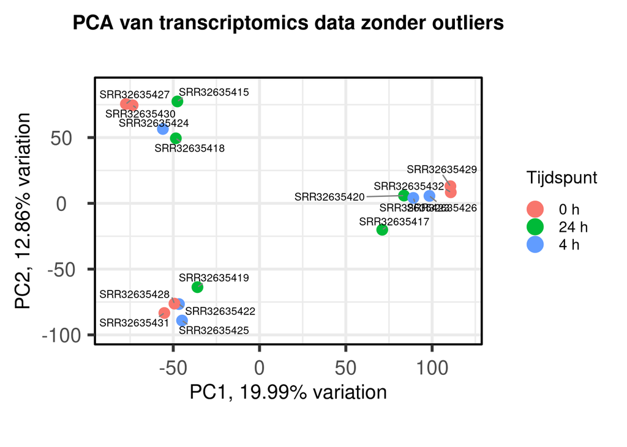

```r
# PCA uitvoeren
p <- pca(
  mat = as.matrix(counts_without_outliers),
  metadata = metadata_without_outliers,
  removeVar = 0.1
)

# PCA plot maken
pca_plot <- biplot(
  p,
  colby = "group",
  lab = metadata_without_outliers$sample,
  legendPosition = "right",
  title = "PCA van transcriptomics data zonder outliers"
) +
  labs(
    color = "Tijdspunt"
  ) +
  theme(
    plot.title = element_text(hjust = 0.5)
  )

pca_plot
```

Op basis van overleg met de projectgroep, Marcel en Tsjerk lijkt een fout of inconsistentie in de oorspronkelijke data-annotatie of data-aanlevering een mogelijke verklaring. We kunnen dit echter niet bevestigen met de beschikbare bestanden. Daarom wordt dit als beperking/onzekerheid meegenomen en niet als bewezen oorzaak gepresenteerd.

### Referenties

Ik heb referenties gebruikt voor de theorie en voor de gebruikte libraries. Hier zal ik onderscheid in maken bij de referenties.

### Gebruikte software

[dplyr](https://cran.r-project.org/web/packages/dplyr/index.html) [readr](https://cran.r-project.org/web/packages/readr/index.html) [tidyr](https://cran.r-project.org/web/packages/tidyr/index.html) [tidyverse](https://cran.r-project.org/web/packages/tidyverse/index.html) [ggplot2](https://ggplot2.tidyverse.org/) [FactoMineR](https://cran.r-project.org/web/packages/FactoMineR/index.html) [PCAtools](https://www.bioconductor.org/packages/release/bioc/html/PCAtools.html) [ggrepel](https://cran.r-project.org/web/packages/ggrepel/index.html) [DESeq2](https://bioconductor.org/packages/release/bioc/html/DESeq2.html)